# chapter3.Rmd

Vishal

2/8/2017

#### Access the libraries needed for the exercise

```r
library(dplyr)
```

```r
library(ggplot2)
library(boot)
```

#### 2. Read and explore the data

```r
alc = read.table("http://s3.amazonaws.com/assets.datacamp.com/production/course_2218/datasets/alc.txt", sep = ",", header = T)
```

```r
dim(alc)
```

```
## [1] 382  35
```

```r
head(alc)
```

```
##   school sex age address famsize Pstatus Medu Fedu     Mjob     Fjob
## 1     GP   F  18       U     GT3       A    4    4  at_home  teacher
## 2     GP   F  17       U     GT3       T    1    1  at_home    other
## 3     GP   F  15       U     LE3       T    1    1  at_home    other
## 4     GP   F  15       U     GT3       T    4    2   health services
## 5     GP   F  16       U     GT3       T    3    3    other    other
## 6     GP   M  16       U     LE3       T    4    3 services    other
##       reason nursery internet guardian traveltime studytime failures
## 1     course     yes       no   mother          2         2        0
## 2     course      no      yes   father          1         2        0
## 3      other     yes      yes   mother          1         2        3
## 4       home     yes      yes   mother          1         3        0
## 5       home     yes       no   father          1         2        0
## 6 reputation     yes      yes   mother          1         2        0
##   schoolsup famsup paid activities higher romantic famrel freetime goout
## 1       yes     no   no         no    yes       no      4        3     4
## 2        no    yes   no         no    yes       no      5        3     3
## 3       yes     no  yes         no    yes       no      4        3     2
## 4        no    yes  yes        yes    yes      yes      3        2     2
## 5        no    yes  yes         no    yes       no      4        3     2
## 6        no    yes  yes        yes    yes       no      5        4     2
##   Dalc Walc health absences G1 G2 G3 alc_use high_use
## 1    1    1      3        6  5  6  6     1.0    FALSE
## 2    1    1      3        4  5  5  6     1.0    FALSE
## 3    2    3      3       10  7  8 10     2.5     TRUE
## 4    1    1      5        2 15 14 15     1.0    FALSE
## 5    1    2      5        4  6 10 10     1.5    FALSE
## 6    1    2      5       10 15 15 15     1.5    FALSE
```

```r
str(alc)
```

```
## 'data.frame':    382 obs. of  35 variables:
##  $ school    : Factor w/ 2 levels "GP","MS": 1 1 1 1 1 1 1 1 1 1 ...
##  $ sex       : Factor w/ 2 levels "F","M": 1 1 1 1 1 2 2 1 2 2 ...
##  $ age       : int  18 17 15 15 16 16 16 17 15 15 ...
##  $ address   : Factor w/ 2 levels "R","U": 2 2 2 2 2 2 2 2 2 2 ...
##  $ famsize   : Factor w/ 2 levels "GT3","LE3": 1 1 2 1 1 2 2 1 2 1 ...
##  $ Pstatus   : Factor w/ 2 levels "A","T": 1 2 2 2 2 2 2 1 1 2 ...
##  $ Medu      : int  4 1 1 4 3 4 2 4 3 3 ...
##  $ Fedu      : int  4 1 1 2 3 3 2 4 2 4 ...
##  $ Mjob      : Factor w/ 5 levels "at_home","health",..: 1 1 1 2 3 4 3 3 4 3 ...
##  $ Fjob      : Factor w/ 5 levels "at_home","health",..: 5 3 3 4 3 3 3 5 3 3 ...
##  $ reason    : Factor w/ 4 levels "course","home",..: 1 1 3 2 2 4 2 2 2 2 ...
##  $ nursery   : Factor w/ 2 levels "no","yes": 2 1 2 2 2 2 2 2 2 2 ...
##  $ internet  : Factor w/ 2 levels "no","yes": 1 2 2 2 1 2 2 1 2 2 ...
##  $ guardian  : Factor w/ 3 levels "father","mother",..: 2 1 2 2 1 2 2 2 2 2 ...
```

[output cut: 21 more lines]

*This data comes from student alcohol consumption dataset, Porto (Portugal).*

*After cleaning the data, we end up with 382 subjects and 35 variables to analyse.*

#### 3. Purpose of analysis

*The 4 variables that I have chosen for the analysis are:*

*1. failures: When someone fails, the chances of drug/alcohol consumption is high*

*2. health: I don’t think that the state of health has any effect on alcohol consumption, however there might be a chance that unhealthy people tend to consume more alcohol*

*3. age: In general, adults of all ages drink, so I don’t think it accounts fot high alcohol consumption*

*4. freetime: This factor could play a significant role in alcohol consumption. If one is bored/have nothing to do, they may tend to consume more alcohol.*

#### 4. More about data

*Numerically and graphically explore the distributions of chosen variables and their relationships with alcohol consumption*

*Box plots are made with and without sex differences*

*Comments and comparision of findings and result at the end of this section*

##### Numerical distribution of failures

```r
alc %>% group_by(high_use, sex, failures) %>% summarise(count =n())
```

```
## Source: local data frame [16 x 4]
## Groups: high_use, sex [?]
##
##    high_use    sex failures count
##       <lgl> <fctr>    <int> <int>
## 1     FALSE      F        0   136
## 2     FALSE      F        1    14
## 3     FALSE      F        2     3
## 4     FALSE      F        3     4
## 5     FALSE      M        0    98
## 6     FALSE      M        1     8
## 7     FALSE      M        2     2
## 8     FALSE      M        3     5
## 9      TRUE      F        0    32
## 10     TRUE      F        1     2
## 11     TRUE      F        2     5
## 12     TRUE      F        3     2
## 13     TRUE      M        0    50
## 14     TRUE      M        1    14
## 15     TRUE      M        2     1
## 16     TRUE      M        3     6
```

##### Graphical distribution of failures

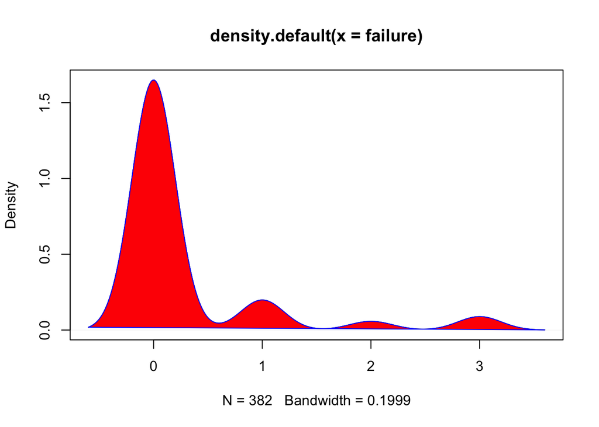

```r
failure = alc$failures
d=density(failure)
plot(d)
polygon(d, col="red", border="blue")
```

##### Relationship of failures with alcohol consumption

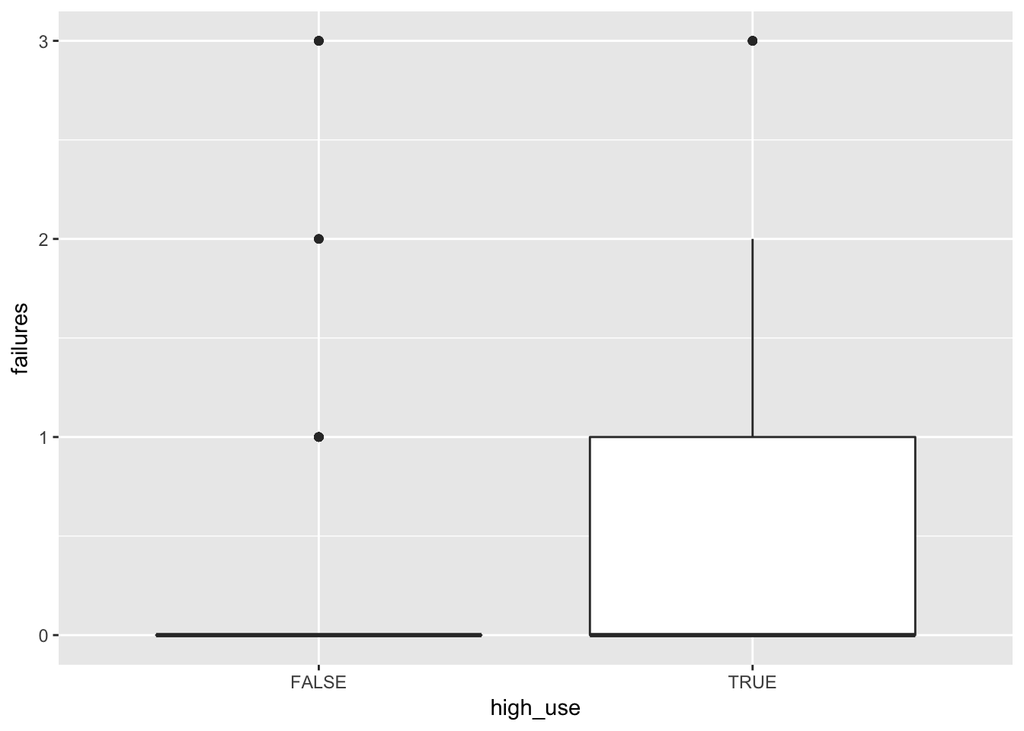

```r
ga <- ggplot(alc, aes(x = high_use, y = failures))
ga + geom_boxplot()
```

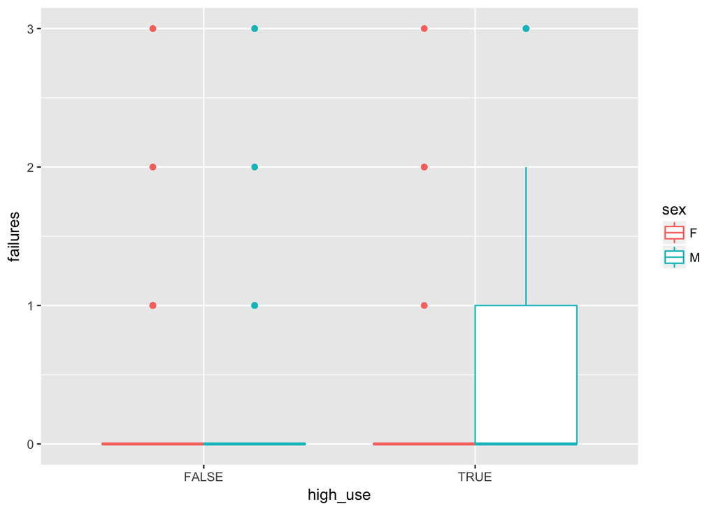

```r
g1 <- ggplot(alc, aes(x = high_use, y = failures, col =sex))
g1 + geom_boxplot()
```

##### Numerical distribution of health

```r
alc %>% group_by(high_use, sex, health) %>% summarise(count =n())
```

```
## Source: local data frame [20 x 4]
## Groups: high_use, sex [?]
##
##    high_use    sex health count
##       <lgl> <fctr>  <int> <int>
## 1     FALSE      F      1    24
## 2     FALSE      F      2    15
## 3     FALSE      F      3    39
## 4     FALSE      F      4    34
## 5     FALSE      F      5    45
## 6     FALSE      M      1    11
## 7     FALSE      M      2    14
## 8     FALSE      M      3    24
## 9     FALSE      M      4    13
## 10    FALSE      M      5    51
## 11     TRUE      F      1     6
## 12     TRUE      F      2     9
## 13     TRUE      F      3     5
## 14     TRUE      F      4     5
## 15     TRUE      F      5    16
## 16     TRUE      M      1     5
## 17     TRUE      M      2     5
## 18     TRUE      M      3    15
## 19     TRUE      M      4    12
## 20     TRUE      M      5    34
```

##### Graphical distribution of health

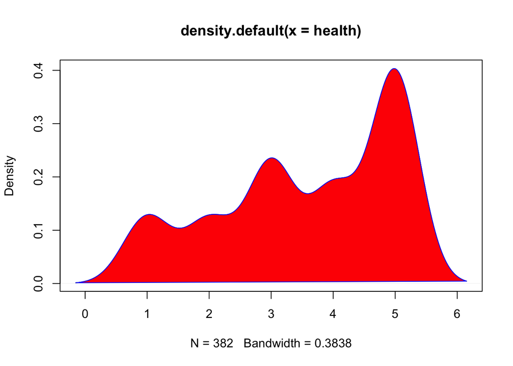

```r
health = alc$health
d=density(health)
plot(d)
polygon(d, col="red", border="blue")
```

##### Relationship of health with alcohol consumption

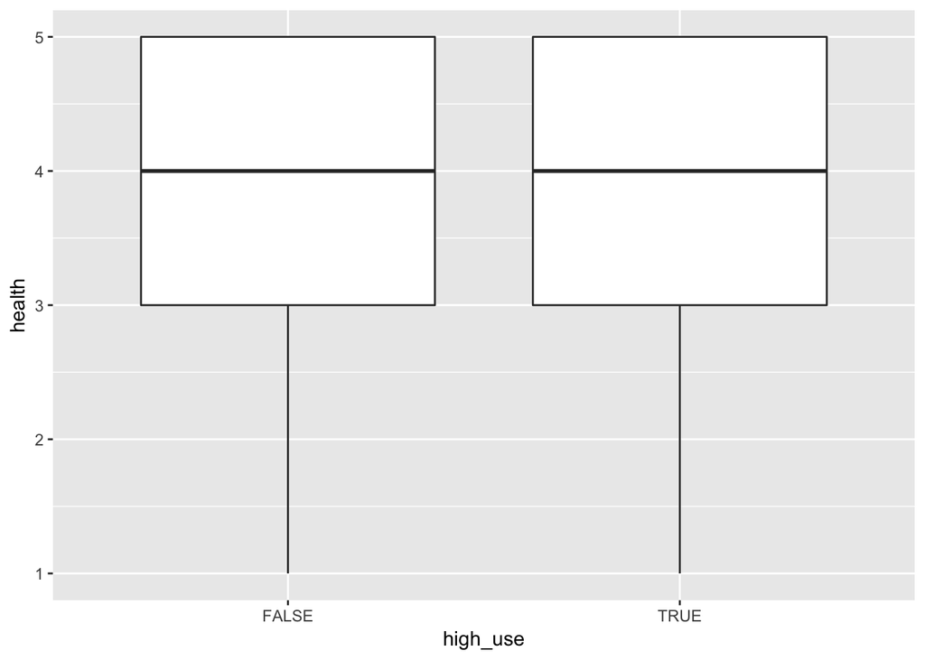

```r
gb <- ggplot(alc, aes(x = high_use, y = health))
gb + geom_boxplot()
```

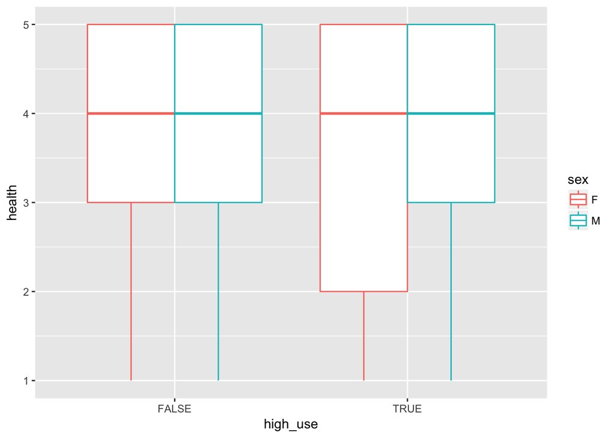

```r
g2 <- ggplot(alc, aes(x = high_use, y = health, col =sex))
g2 + geom_boxplot()
```

##### Numerical distribution of age

```r
alc %>% group_by(high_use, sex, age) %>% summarise(count =n())
```

```
## Source: local data frame [22 x 4]
## Groups: high_use, sex [?]
##
##    high_use    sex   age count
##       <lgl> <fctr> <int> <int>
## 1     FALSE      F    15    29
## 2     FALSE      F    16    42
## 3     FALSE      F    17    46
## 4     FALSE      F    18    37
## 5     FALSE      F    19     3
## 6     FALSE      M    15    34
## 7     FALSE      M    16    37
## 8     FALSE      M    17    19
## 9     FALSE      M    18    18
## 10    FALSE      M    19     4
## # ... with 12 more rows
```

##### Graphical distribution of age

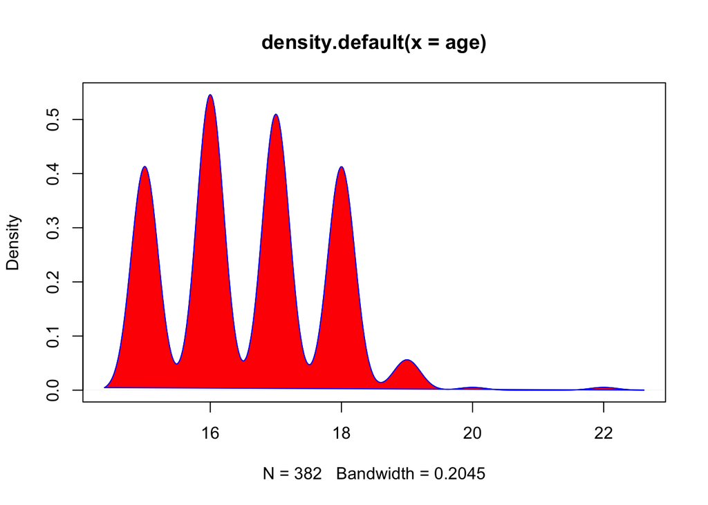

```r
age = alc$age
d=density(age)
plot(d)
polygon(d, col="red", border="blue")
```

##### Relationship of age with alcohol consumption

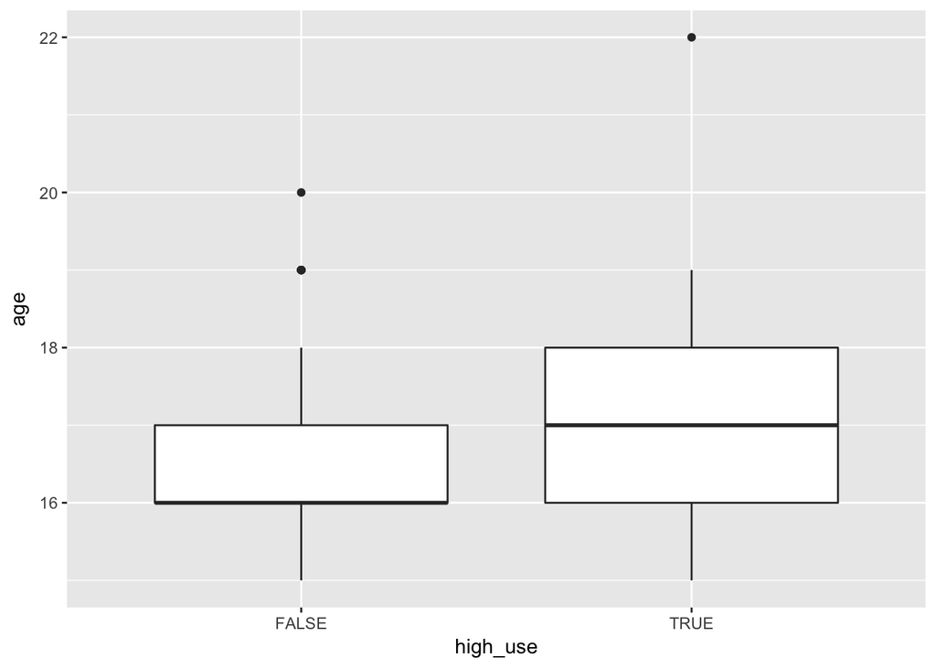

```r
gc <- ggplot(alc, aes(x = high_use, y = age))
gc + geom_boxplot()
```

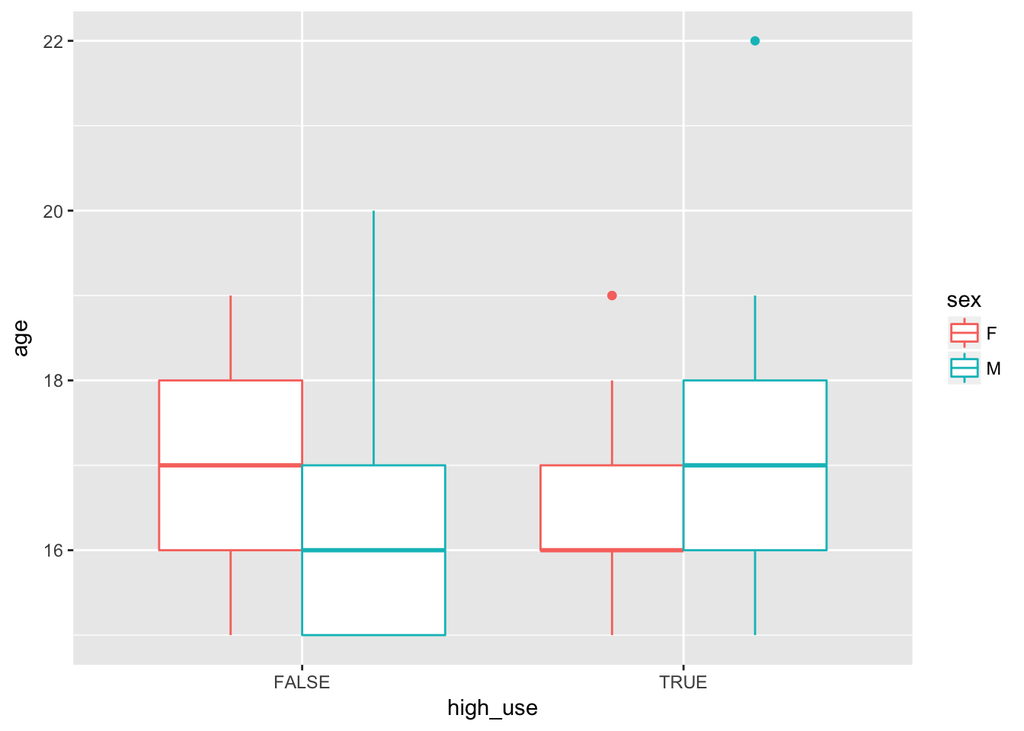

```r
g3 <- ggplot(alc, aes(x = high_use, y = age, col = sex))
g3 + geom_boxplot()
```

##### Numerical distribution of freetime

```r
alc %>% group_by(high_use, sex, freetime) %>% summarise(count =n())
```

```
## Source: local data frame [19 x 4]
## Groups: high_use, sex [?]
##
##    high_use    sex freetime count
##       <lgl> <fctr>    <int> <int>
## 1     FALSE      F        1    14
## 2     FALSE      F        2    30
## 3     FALSE      F        3    72
## 4     FALSE      F        4    35
## 5     FALSE      F        5     6
## 6     FALSE      M        1     2
## 7     FALSE      M        2    17
## 8     FALSE      M        3    44
## 9     FALSE      M        4    34
## 10    FALSE      M        5    16
## 11     TRUE      F        2     5
## 12     TRUE      F        3    19
## 13     TRUE      F        4    15
## 14     TRUE      F        5     2
## 15     TRUE      M        1     2
## 16     TRUE      M        2    10
## 17     TRUE      M        3    21
## 18     TRUE      M        4    25
## 19     TRUE      M        5    13
```

##### Graphical distribution of freetime

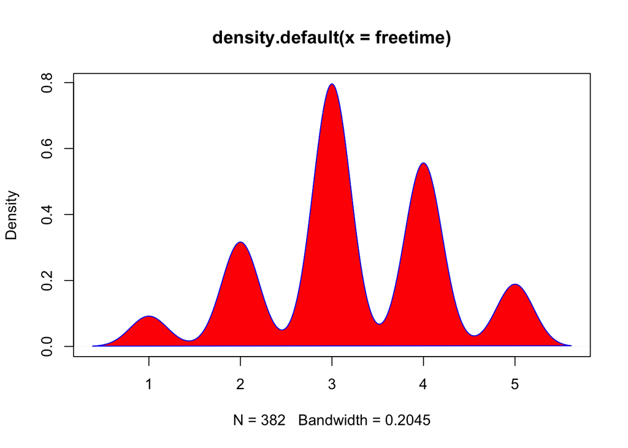

```r
freetime = alc$freetime
d=density(freetime)
plot(d)
polygon(d, col="red", border="blue")
```

##### Relationship of freetime with alcohol consumption

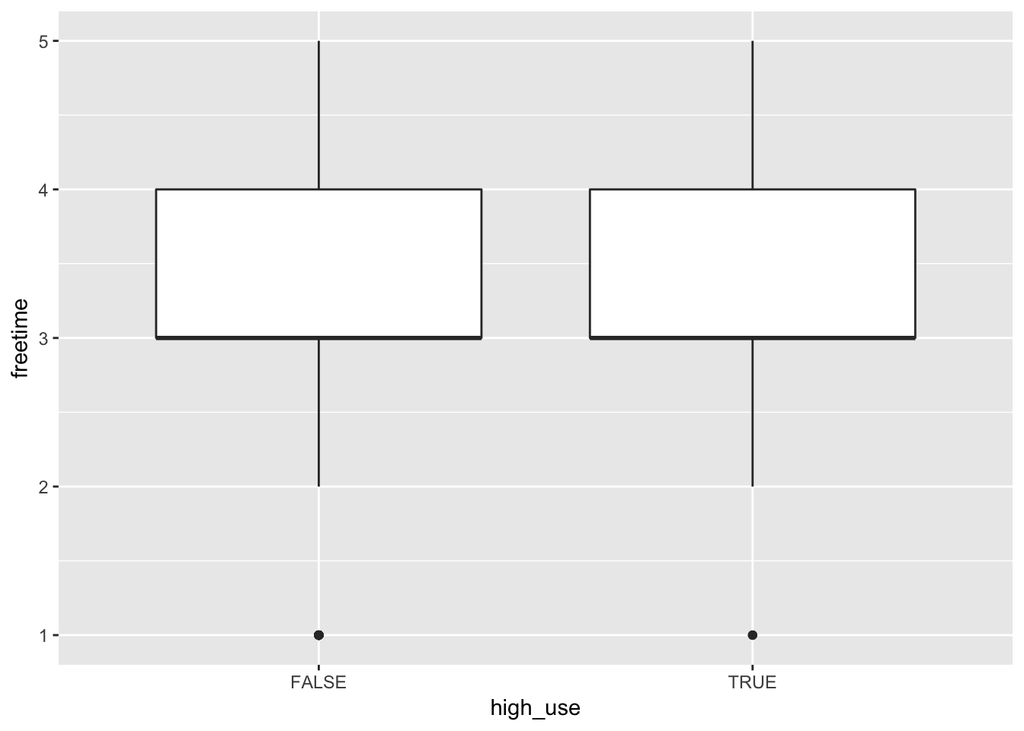

```r
gd <- ggplot(alc, aes(x = high_use, y = freetime))
gd + geom_boxplot()
```

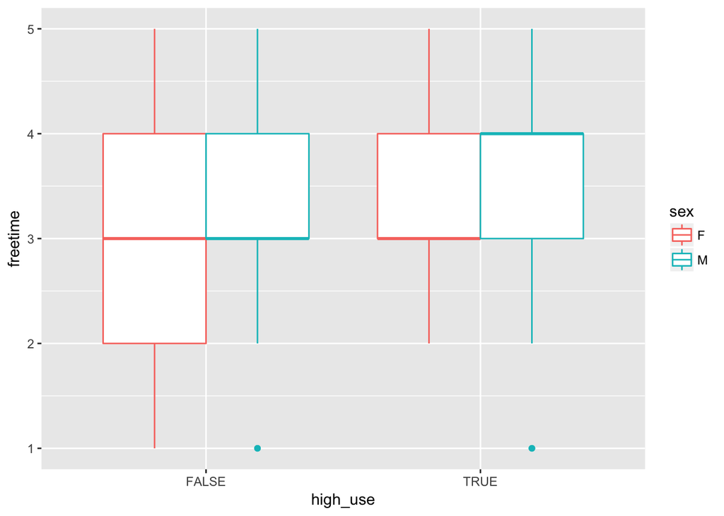

```r
g4 <- ggplot(alc, aes(x = high_use, y = freetime, col =sex))
g4 + geom_boxplot()
```

*From the density plots, we can clearly see that only freetime is normally distribued. Other variables are skewed and don’t follow normal distribution.*

*From box plot, it seems that failures has an effect on alcohol consumption. Whereas health age an freetime don’t have a significant relationship with alcohol consumption.*

*Comparing it to the previously stated hypothesis, everything is in concordance except freetime as I initially thought that freetime affects alcohol consumption.*

#### 5. Logistic regression to explore the relationship b/w chosen variables and alcohol consumption

```r
m <- glm(high_use ~ failures + health + age + freetime, data = alc, family = "binomial")
summary(m)
```

```
##
## Call:
## glm(formula = high_use ~ failures + health + age + freetime,
##     family = "binomial", data = alc)
##
## Deviance Residuals:
##     Min       1Q   Median       3Q      Max
## -1.6185  -0.8271  -0.7121   1.2833   2.0237
##
## Coefficients:
##             Estimate Std. Error z value Pr(>|z|)
## (Intercept) -5.18073    1.76260  -2.939  0.00329 **
## failures     0.33431    0.15015   2.226  0.02598 *
## health       0.08933    0.08489   1.052  0.29265
## age          0.16966    0.09955   1.704  0.08835 .
## freetime     0.31847    0.12057   2.641  0.00826 **
## ---
## Signif. codes:  0 '***' 0.001 '**' 0.01 '*' 0.05 '.' 0.1 ' ' 1
##
## (Dispersion parameter for binomial family taken to be 1)
##
##     Null deviance: 462.21  on 381  degrees of freedom
## Residual deviance: 442.58  on 377  degrees of freedom
## AIC: 452.58
##
## Number of Fisher Scoring iterations: 4
```

```r
coef(m)
```

```
## (Intercept)    failures      health         age    freetime
## -5.18073413  0.33431490  0.08932739  0.16965556  0.31847032
```

```r
OR <- coef(m) %>% exp
OR
```

```
## (Intercept)    failures      health         age    freetime
## 0.005623876 1.396982988 1.093438576 1.184896660 1.375022805
```

```r
CI <- confint(m) %>% exp
CI
```

```
##                    2.5 %    97.5 %
## (Intercept) 0.0001664349 0.1699432
## failures    1.0399367080 1.8815762
## health      0.9274606199 1.2946599
## age         0.9760886814 1.4434958
## freetime    1.0888815402 1.7486579
```

```r
cbind(OR, CI)
```

```
##                      OR        2.5 %    97.5 %
## (Intercept) 0.005623876 0.0001664349 0.1699432
## failures    1.396982988 1.0399367080 1.8815762
## health      1.093438576 0.9274606199 1.2946599
## age         1.184896660 0.9760886814 1.4434958
## freetime    1.375022805 1.0888815402 1.7486579
```

*In this logistic regression model, we are explaining the variable points i.e. failure, health, age and freetime against high alcohol use. Based on the regression model, failure and freetime have significant relationship with high alcohol use. health and age show no significant relationship with high alcohol use. Intercept is around -5.2, so if explanatory variables are 0, high alcohol use should be around -5.2.*

*Odds ratio for the significant variables failure and freetime are 1.39 and 1.37 respectively. It means that both failures and freetime increase the risk of high alcohol consumption by the factor of around 1.4.The condidence intervals are shown in the table above.*

### CV results keep on changing while knitting because of randomisation of the data. Please keep this in mind, the value written in the report won’t match the results so don’t deduct the points for it.

#### 6. Variables which have a statistical relationship with alcohol consumption

```r
m <- glm(high_use ~ failures + freetime, data = alc, family = "binomial")
summary(m)
```

```
##
## Call:
## glm(formula = high_use ~ failures + freetime, family = "binomial",
##     data = alc)
##
## Deviance Residuals:
##     Min       1Q   Median       3Q      Max
## -1.4863  -0.8706  -0.7588   1.3198   1.9520
##
## Coefficients:
##             Estimate Std. Error z value Pr(>|z|)
## (Intercept)  -2.0671     0.4175  -4.951 7.37e-07 ***
## failures      0.3845     0.1467   2.621  0.00876 **
## freetime      0.3231     0.1198   2.696  0.00702 **
## ---
## Signif. codes:  0 '***' 0.001 '**' 0.01 '*' 0.05 '.' 0.1 ' ' 1
##
## (Dispersion parameter for binomial family taken to be 1)
##
##     Null deviance: 462.21  on 381  degrees of freedom
## Residual deviance: 446.38  on 379  degrees of freedom
## AIC: 452.38
##
## Number of Fisher Scoring iterations: 4
```

```r
probabilities <- predict(m, type = "response")
alc <- mutate(alc, probability = probabilities)
alc <- mutate(alc, prediction = probability > 0.5)
table(high_use = alc$high_use, prediction = alc$prediction)
```

```
##         prediction
## high_use FALSE TRUE
##    FALSE   261    9
##    TRUE    105    7
```

```r
table(high_use = alc$high_use, prediction = alc$prediction)%>% prop.table() %>% addmargins()
```

```
##         prediction
## high_use      FALSE       TRUE        Sum
##    FALSE 0.68324607 0.02356021 0.70680628
##    TRUE  0.27486911 0.01832461 0.29319372
##    Sum   0.95811518 0.04188482 1.00000000
```

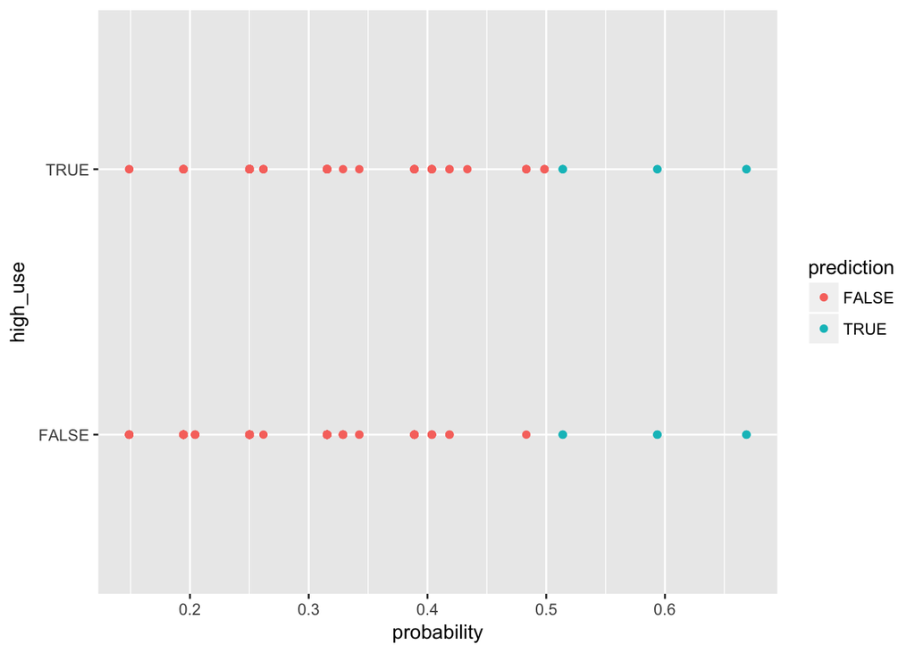

```r
plot=ggplot(alc, aes(x = probability, y = high_use, col = prediction))
plot+geom_point()
```

```r
loss_func <- function(class, prob) {
  n_wrong <- abs(class - prob) > 0.5
  mean(n_wrong)
}
loss_func(class = alc$high_use, prob = alc$probability)
```

```
## [1] 0.2984293
```

*The regression model gives better significance (p-values) than the previous model when the insignificant variables are excluded. Also, The model predicted FALSE when it actually was FALSE 68% of time and TRUE when it was TRUE 2% of time.The overall loss/wrong prediction of the model is 0.298 or around 30%*

#### 7. BONUS Cross validation

```r
cv <- cv.glm(data = alc, cost = loss_func, glmfit = m, K = 10)
cv$delta[1]
```

```
## [1] 0.2958115
```

*The model error using 10 fold cross validation is 0.2958. The model doesn’t improve much after CV (0.298) and also couldn’t be made better to compared to the model in DataCamp (0.26). The reason is that the variables decide the outcome of the model and different chosen variables have different outcomes.*

#### Better model than DataCamp exercise

*Predictors are famrel, freetime and goout*

*Model error = 0.249*

```r
m <- glm(high_use ~ famrel + freetime + goout, data = alc, family = "binomial")
summary(m)
```

```
##
## Call:
## glm(formula = high_use ~ famrel + freetime + goout, family = "binomial",
##     data = alc)
##
## Deviance Residuals:
##     Min       1Q   Median       3Q      Max
## -1.6778  -0.7873  -0.5624   0.9771   2.4260
##
## Coefficients:
##             Estimate Std. Error z value Pr(>|z|)
## (Intercept)  -2.2158     0.6582  -3.367 0.000761 ***
## famrel       -0.4493     0.1355  -3.316 0.000913 ***
## freetime      0.1863     0.1354   1.376 0.168824
## goout         0.7518     0.1226   6.132 8.66e-10 ***
## ---
## Signif. codes:  0 '***' 0.001 '**' 0.01 '*' 0.05 '.' 0.1 ' ' 1
##
## (Dispersion parameter for binomial family taken to be 1)
##
##     Null deviance: 462.21  on 381  degrees of freedom
## Residual deviance: 400.42  on 378  degrees of freedom
## AIC: 408.42
##
## Number of Fisher Scoring iterations: 4
```

```r
probabilities <- predict(m, type = "response")
alc <- mutate(alc, probability = probabilities)
alc <- mutate(alc, prediction = probability > 0.5)
loss_func <- function(class, prob) {
  n_wrong <- abs(class - prob) > 0.5
  mean(n_wrong)
}
loss_func(class = alc$high_use, prob = alc$probability)
```

```
## [1] 0.2460733
```

```r
cv <- cv.glm(data = alc, cost = loss_func, glmfit = m, K = 10)
cv$delta[1]
```

```
## [1] 0.2513089
```

#### 8. SUPERBONUS

*Didn’t plot the graph*

```r
m <- glm(high_use ~ famrel + freetime + goout + sex + failures + health + studytime, data = alc, family = "binomial")
summary(m)
```

```
##
## Call:
## glm(formula = high_use ~ famrel + freetime + goout + sex + failures +
##     health + studytime, family = "binomial", data = alc)
##
## Deviance Residuals:
##     Min       1Q   Median       3Q      Max
## -1.7443  -0.7532  -0.4947   0.8129   2.6350
##
## Coefficients:
##             Estimate Std. Error z value Pr(>|z|)
## (Intercept) -1.78476    0.81326  -2.195 0.028194 *
## famrel      -0.47922    0.14178  -3.380 0.000725 ***
## freetime     0.07604    0.14055   0.541 0.588466
## goout        0.77220    0.12675   6.092 1.11e-09 ***
## sexM         0.70164    0.27045   2.594 0.009478 **
## failures     0.14677    0.17195   0.854 0.393360
## health       0.11681    0.09437   1.238 0.215777
## studytime   -0.43556    0.17341  -2.512 0.012015 *
## ---
## Signif. codes:  0 '***' 0.001 '**' 0.01 '*' 0.05 '.' 0.1 ' ' 1
##
## (Dispersion parameter for binomial family taken to be 1)
##
##     Null deviance: 462.21  on 381  degrees of freedom
## Residual deviance: 376.38  on 374  degrees of freedom
## AIC: 392.38
##
## Number of Fisher Scoring iterations: 4
```

```r
probabilities <- predict(m, type = "response")
alc <- mutate(alc, probability = probabilities)
alc <- mutate(alc, prediction = probability > 0.5)
loss_func <- function(class, prob) {
  n_wrong <- abs(class - prob) > 0.5
  mean(n_wrong)
}
loss_func(class = alc$high_use, prob = alc$probability)
```

```
## [1] 0.2277487
```

```r
cv <- cv.glm(data = alc, cost = loss_func, glmfit = m, K = 10)
cv$delta[1]
```

```
## [1] 0.2486911
```

*Significant variables = famrel, goout, sex, studytime*

*Dropping 3 insignificant variables : freetime, failures, health*

```r
m <- glm(high_use ~ famrel + goout + sex + studytime, data = alc, family = "binomial")
summary(m)
```

```
##
## Call:
## glm(formula = high_use ~ famrel + goout + sex + studytime, family = "binomial",
##     data = alc)
##
## Deviance Residuals:
##     Min       1Q   Median       3Q      Max
## -1.5928  -0.7494  -0.4919   0.8250   2.7080
##
## Coefficients:
##             Estimate Std. Error z value Pr(>|z|)
## (Intercept)  -1.2112     0.7142  -1.696  0.08991 .
## famrel       -0.4496     0.1379  -3.260  0.00111 **
## goout         0.7947     0.1218   6.523 6.89e-11 ***
## sexM          0.7593     0.2655   2.860  0.00424 **
## studytime    -0.4752     0.1703  -2.790  0.00527 **
## ---
## Signif. codes:  0 '***' 0.001 '**' 0.01 '*' 0.05 '.' 0.1 ' ' 1
##
## (Dispersion parameter for binomial family taken to be 1)
##
##     Null deviance: 462.21  on 381  degrees of freedom
## Residual deviance: 379.27  on 377  degrees of freedom
## AIC: 389.27
##
## Number of Fisher Scoring iterations: 4
```

```r
probabilities <- predict(m, type = "response")
alc <- mutate(alc, probability = probabilities)
alc <- mutate(alc, prediction = probability > 0.5)
loss_func <- function(class, prob) {
  n_wrong <- abs(class - prob) > 0.5
  mean(n_wrong)
}
loss_func(class = alc$high_use, prob = alc$probability)
```

```
## [1] 0.2408377
```

```r
cv <- cv.glm(data = alc, cost = loss_func, glmfit = m, K = 10)
cv$delta[1]
```

```
## [1] 0.2303665
```

*Model error = 0.24*

```r
m <- glm(high_use ~ famrel + sex + studytime, data = alc, family = "binomial")
summary(m)
```

```
##
## Call:
## glm(formula = high_use ~ famrel + sex + studytime, family = "binomial",
##     data = alc)
##
## Deviance Residuals:
##     Min       1Q   Median       3Q      Max
## -1.5550  -0.8415  -0.6547   1.2299   2.1761
##
## Coefficients:
##             Estimate Std. Error z value Pr(>|z|)
## (Intercept)   0.9178     0.5885   1.560  0.11884
## famrel       -0.3257     0.1242  -2.623  0.00872 **
## sexM          0.7336     0.2471   2.968  0.00299 **
## studytime    -0.4711     0.1563  -3.013  0.00258 **
## ---
## Signif. codes:  0 '***' 0.001 '**' 0.01 '*' 0.05 '.' 0.1 ' ' 1
##
## (Dispersion parameter for binomial family taken to be 1)
##
##     Null deviance: 462.21  on 381  degrees of freedom
## Residual deviance: 429.98  on 378  degrees of freedom
## AIC: 437.98
##
## Number of Fisher Scoring iterations: 4
```

```r
probabilities <- predict(m, type = "response")
alc <- mutate(alc, probability = probabilities)
alc <- mutate(alc, prediction = probability > 0.5)
loss_func <- function(class, prob) {
  n_wrong <- abs(class - prob) > 0.5
  mean(n_wrong)
}
loss_func(class = alc$high_use, prob = alc$probability)
```

```
## [1] 0.2958115
```

```r
cv <- cv.glm(data = alc, cost = loss_func, glmfit = m, K = 10)
cv$delta[1]
```

```
## [1] 0.2931937
```

*Model error = 0.29*